# CleanupPBMC

2024-01-03

```r
knitr::opts_chunk$set(echo = TRUE)
library(Seurat)
library(Azimuth)
library(cowplot)
library(patchwork)
library(dplyr)
library(knitr)
library(ggplot2)
library(r2r)
```

## Parameters

Listing parameters definined at the beginning of the rmarkdown document

```
## [1] "workingDirectory -> /Users/sam/Documents/portfolio/datasets/single_cell/"
## [1] "outputFile -> cleanedSamples.rds"
## [1] "maxMito -> 10"
## [1] "minGenes -> 500"
## [1] "maxGenes -> 4000"
## [1] "minAzimuthScore -> 0.9"
```

## Functions

Functions that are used down the line in this script

A function to run Azimuth and do some cleanup

```r
## input is a seurat object
RunAzimuthFunction <- function(this.seurat){
  ## run azimuth
  this.seurat <- RunAzimuth(this.seurat, reference = "pbmcref", verbose = FALSE, n.trees = 50)

  ## only keep cells with a high confidence call
  this.seurat <- subset(this.seurat, subset = predicted.celltype.l1.score >= params$minAzimuthScore)

  ## replace spaces in predicted cell types for easier downstream manipulation
  this.seurat$predicted.celltype.l1 <- gsub(" ", "-", this.seurat$predicted.celltype.l1)
  this.seurat$predicted.celltype.l2 <- gsub(" ", "-", this.seurat$predicted.celltype.l2)
  this.seurat$predicted.celltype.l3 <- gsub(" ", "-", this.seurat$predicted.celltype.l3)

  ## return seurat object
  return(this.seurat)
}
```

A function to compare level assignments from Azimuth per cell

```r
## level3 is "lower" than level2
## level2 is "lower" than level1
## level1 is the "highest", "grossest" level
levelfxn <- function(this.predicted_lower_lvl, this.predicted_higher_lvl) {
  this.matching_higher_lvl <- query(my.hm, this.predicted_lower_lvl)
  if(this.matching_higher_lvl == this.predicted_higher_lvl){
    this.result <- "agree"
  }
  else{
    this.result <- "disagree"
  }
  return(this.result)
}
```

A simple function to format TCR and BCR clonotype information before adding to our Seurat object

```r
immuneRepertoirePrepFunction <- function(this.seurat,this.clonotypes,this.columnName){

  ## let's just keep high quality, high confidence clonotypes
  this.clonotypes <- subset(this.clonotypes, subset = is_cell == "true")
  this.clonotypes <- subset(this.clonotypes, subset = high_confidence == "true")
  this.clonotypes <- subset(this.clonotypes, subset = full_length == "true")
  this.clonotypes <- subset(this.clonotypes, subset = productive == "true")

  ## get unique barcodes for future use
  this.rows <- unique(this.clonotypes$barcode)

  ## generate a new dataframe to return
  this.meta <- as.data.frame(matrix(nrow = length(this.rows), ncol = 1))
  row.names(this.meta) <- this.rows
  colnames(this.meta) <- "clonotypeID"

  ## read through our clonotype table and add to the dataframe to return
  for(i in 1:length(row.names(this.clonotypes))){
    this.barcode <- this.clonotypes[i, "barcode"]
    this.clonotype <- this.clonotypes[i, "raw_clonotype_id"]
    this.meta[this.barcode, "clonotypeID"] <- this.clonotype
  }

  ## add new metadata
  this.seurat <- AddMetaData(this.seurat, this.meta, this.columnName)
  ## return the seurat object
  return(this.seurat)
}
```

A function to remove cells that have both a TCR and BCR clonotype assignment

```r
RemoveDoublePositiveCellsFunction <- function(this.seurat){

  this.meta <- this.seurat@meta.data
  this.meta <- this.meta[!is.na(this.meta$tcrClonotypeID),]
  this.meta <- this.meta[!is.na(this.meta$bcrClonotypeID),]
  print(paste(length(row.names(this.meta)), "cells had TCR and BCR sequences"))
  this.seurat <- subset(this.seurat, cells = c(row.names(this.meta)), invert = TRUE)
}
```

## Building our Seurat object

“pbmc4k” and “pbmc8k” are 3’ GEX libraries.  
“pbmc10K” and “pbmc20K” are 5’ GEX libraries and we’re going to have some fun with that later.

pbmc4k  
https://www.10xgenomics.com/resources/datasets/4-k-pbm-cs-from-a-healthy-donor-2-standard-2-1-0

pbmc8k  
https://www.10xgenomics.com/resources/datasets/8-k-pbm-cs-from-a-healthy-donor-2-standard-2-1-0

pbmc10k  
https://www.10xgenomics.com/resources/datasets/10-k-human-pbm-cs-5-v-2-0-chromium-x-2-standard-6-1-0

pbmc20k  
https://www.10xgenomics.com/datasets/20-k-human-pbm-cs-5-ht-v-2-0-2-high-6-1-0

pbmcRenal  
https://www.ncbi.nlm.nih.gov/geo/query/acc.cgi?acc=GSE233315

```r
## read in public datasets
pbmc4k.data <- Read10X(paste(params$workingDirectory, "pbmc4k/filtered_gene_bc_matrices/GRCh38/", sep = ""))
pbmc8k.data <- Read10X(paste(params$workingDirectory, "pbmc8k/filtered_gene_bc_matrices/GRCh38/", sep = ""))
## a slightly different way to do so
pbmc10k.data <- Read10X_h5(paste(params$workingDirectory, "pbmc10k/10k_PBMC_5pv2_nextgem_Chromium_X_Multiplex_count_raw_feature_bc_matrix.h5", sep = ""))
pbmc20k.data <- Read10X_h5(paste(params$workingDirectory, "pbmc20k/20k_PBMC_5pv2_HT_nextgem_Chromium_X_Multiplex_count_raw_feature_bc_matrix.h5", sep = ""))
pbmcRenal.data <- Read10X(paste(params$workingDirectory, "pbmcRenal/", sep = ""))


## create separate seurat objects
pbmc4k <- CreateSeuratObject(pbmc4k.data, project = "PBMC4K")
pbmc8k <- CreateSeuratObject(pbmc8k.data, project = "PBMC8K")
pbmc10k <- CreateSeuratObject(pbmc10k.data, project = "PBMC10K", min.features = params$minGenes)
pbmc20k <- CreateSeuratObject(pbmc20k.data, project = "PBMC20K", min.features = params$minGenes)
pbmcRenal <- CreateSeuratObject(pbmcRenal.data, project = "PBMCRenal", names.delim = "-", names.field = 2)

## From the 'Data processing' portion of the GEO entry
## "cell barcode appendices: PT is represented by '-1' and NC is represented by '-2'"
pbmcRenalPatient <- subset(pbmcRenal, idents = "1")
pbmcRenalPatient@meta.data$orig.ident <- "pbmcRenalPatient"
pbmcRenalControl <- subset(pbmcRenal, idents = "2")
pbmcRenalControl@meta.data$orig.ident <- "pbmcRenalControl"
```

## Add Clonotype data

The pbmc10k and pbmc20k datasest also have T-cell Receptor (TCR) and B-cell Receptor (BCR) sequencing

We’re going to leverage the cell barcodes to match clonotype data to each cell

```r
## read in TCR clonotype data
my.10k.tcr.clonotypes <- read.csv(paste(params$workingDirectory, "pbmc10k/tcr/10k_PBMC_5pv2_nextgem_Chromium_X_Multiplex_vdj_t_all_contig_annotations.csv", sep = ""))
my.10k.bcr.clonotypes <- read.csv(paste(params$workingDirectory, "pbmc10k/bcr/10k_PBMC_5pv2_nextgem_Chromium_X_Multiplex_vdj_b_all_contig_annotations.csv", sep = ""))

my.20k.tcr.clonotypes <- read.csv(paste(params$workingDirectory, "pbmc20k/tcr/20k_PBMC_5pv2_HT_nextgem_Chromium_X_Multiplex_vdj_t_all_contig_annotations.csv", sep = ""))
my.20k.bcr.clonotypes <- read.csv(paste(params$workingDirectory, "pbmc20k/bcr/20k_PBMC_5pv2_HT_nextgem_Chromium_X_Multiplex_vdj_b_all_contig_annotations.csv", sep = ""))

## add clonotype information to metadata
pbmc10k <- immuneRepertoirePrepFunction(pbmc10k, my.10k.tcr.clonotypes, "tcrClonotypeID")
pbmc10k <- immuneRepertoirePrepFunction(pbmc10k, my.10k.bcr.clonotypes, "bcrClonotypeID")
pbmc20k <- immuneRepertoirePrepFunction(pbmc20k, my.20k.tcr.clonotypes, "tcrClonotypeID")
pbmc20k <- immuneRepertoirePrepFunction(pbmc20k, my.20k.bcr.clonotypes, "bcrClonotypeID")

## remove cells that have both a TCR and BCR, which isn't biologically possible
pbmc10k <- RemoveDoublePositiveCellsFunction(pbmc10k)
```

```
## [1] "33 cells had TCR and BCR sequences"
```

```r
pbmc20k <- RemoveDoublePositiveCellsFunction(pbmc20k)
```

```
## [1] "93 cells had TCR and BCR sequences"
```

## Merge Our Seurat Objects

```r
## merge seurat objects and give them descriptive names
pbmc <- merge(x = pbmc4k, y = c(pbmc8k, pbmc10k, pbmc20k, pbmcRenalPatient, pbmcRenalControl), add.cell.ids = c("4K", "8K", "10K", "20K", "RenalPatient", "RenalControl"), project = "PBMC")

## save some space and remove unneeded objects
rm(pbmc4k, pbmc4k.data, pbmc8k, pbmc8k.data, pbmc10k, pbmc10k.data, pbmc20k, pbmc20k.data, pbmcRenalPatient,pbmcRenalControl,pbmcRenal.data, pbmcRenal )
```

## Initial Quality Control

Plotting the initial states

```r
## grab the maximum values for x and y scaling, especially after removing cells
max.nCount <- max(pbmc$nCount_RNA)
max.nFeature <- max(pbmc$nFeature_RNA)

## calculate the percent mitochondrial for each cell
pbmc[["percent.mt"]] <- PercentageFeatureSet(pbmc, pattern = "^MT-")

## plot nCount_RNA by percent.mt
## nCount_RNA is really the number of aligned reads per cell
pre.nCount_by_perc.mt <- FeatureScatter(pbmc, feature1 = "nCount_RNA", feature2 = "percent.mt", raster=FALSE)

## set the x and y axis scales
## remove the legend because we won't need it
## rotate the x-axis labels so they don't run into each other
pre.nCount_by_perc.mt <- pre.nCount_by_perc.mt + ylim(0,100) + xlim(0, max.nCount) + NoLegend() + theme(axis.text.x = element_text(angle = 45, vjust = 0.5))

## plot nCount_RNA by nFeature_RNA
## nFeature_RNA is really the number of genes detected per cell
pre.nCount_by_nFeature <- FeatureScatter(pbmc, feature1 = "nCount_RNA", feature2 = "nFeature_RNA", raster=FALSE)

## set the x and y axis scales
## remove the legend because we won't need it
## rotate the x-axis labels so they don't run into each other
pre.nCount_by_nFeature <- pre.nCount_by_nFeature + ylim(0, max.nFeature) + xlim(0, max.nCount) + NoLegend() + theme(axis.text.x = element_text(angle = 45, vjust = 0.5))
```

Removing cells based on criteria in “params” section and plotting results

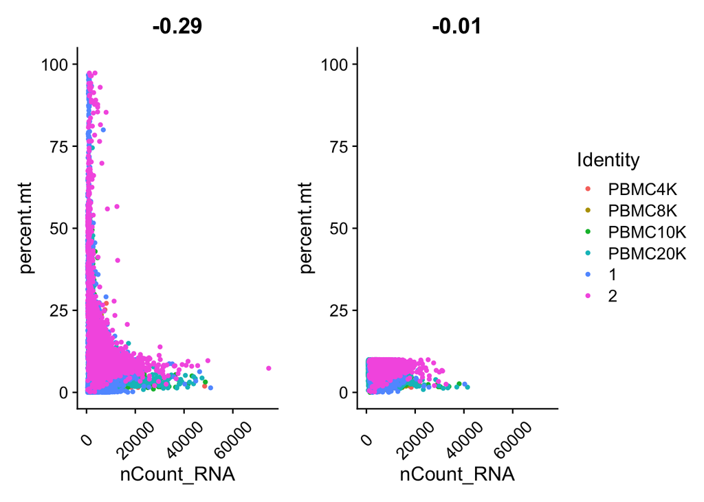

```r
## remove cells based on criteria determined in the setup portion
pbmc <- subset(pbmc, subset = nFeature_RNA >= params$minGenes & nFeature_RNA <= params$maxGenes & percent.mt <= params$maxMito)

## plot nCount_RNA by nFeature_RNA after cell removal
after.nCount_by_perc.mt <- FeatureScatter(pbmc, feature1 = "nCount_RNA", feature2 = "percent.mt")

## set the x and y axis scales
## rotate the x-axis labels so they don't run into each other
after.nCount_by_perc.mt <- after.nCount_by_perc.mt + ylim(0,100) + xlim(0, max.nCount) + theme(axis.text.x = element_text(angle = 45, vjust = 0.5))

## plot nCount_RNA by nFeature_RNA
after.nCount_by_nFeature <- FeatureScatter(pbmc, feature1 = "nCount_RNA", feature2 = "nFeature_RNA")

## set the x and y axis scales
## rotate the x-axis labels so they don't run into each other
after.nCount_by_nFeature <- after.nCount_by_nFeature + ylim(0, max.nFeature) + xlim(0, max.nCount) + theme(axis.text.x = element_text(angle = 45, vjust = 0.5))

## Now when we combine two images, they'll be side by side
par(mfrow=c(2,1))

## combine images and plot them
p <- pre.nCount_by_perc.mt + after.nCount_by_perc.mt
plot(p)
```

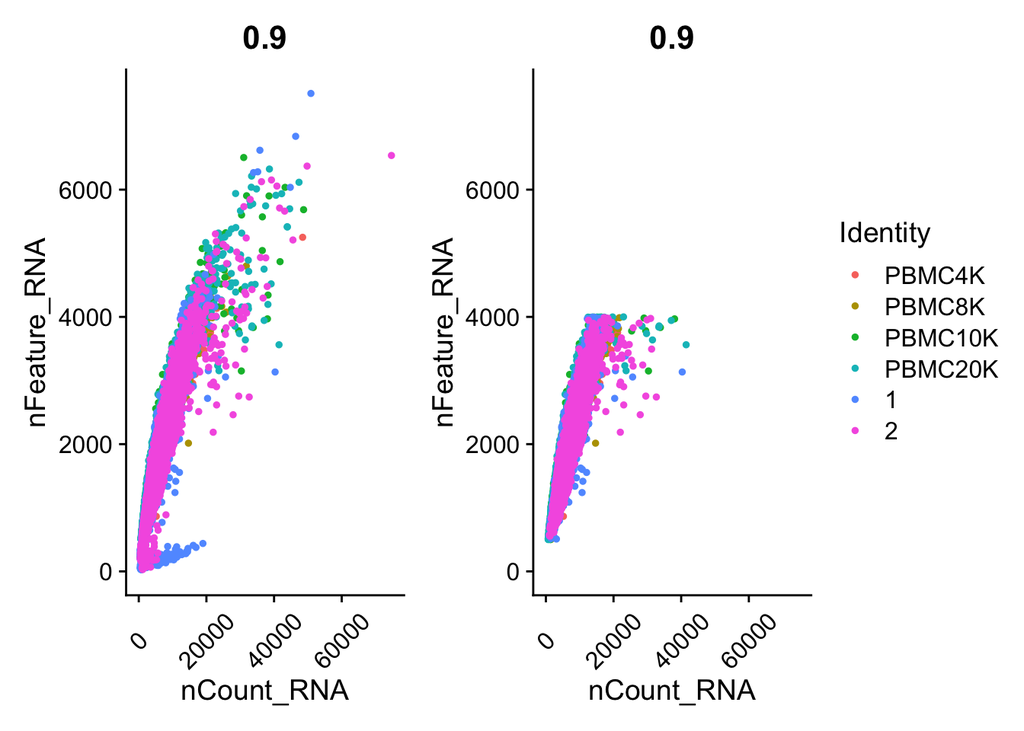

```r
## combine images and plot them
p <- pre.nCount_by_nFeature + after.nCount_by_nFeature
plot(p)
```

```r
## what up with our object after removing cells?
pbmc
```

```
## An object of class Seurat
## 85985 features across 46483 samples within 1 assay
## Active assay: RNA (85985 features, 0 variable features)
##  6 layers present: counts.1, counts.2, counts.3, counts.4, counts.5, counts.6
```

## Determining cell types with Azimuth

```r
## let's split our seurat object by the original identity because Azimuth can be a
## little memory intensive and we can run them separately
my.obj.list <- SplitObject(pbmc, split.by = "orig.ident")

## we can remove the pbmc seurat object after splitting because we don't need it
rm(pbmc)

## run azimuth and cleanup on each seurat object in our list
my.obj.list <- lapply(X = my.obj.list, FUN = function(x){
  x <- RunAzimuthFunction(x)
})

## let's merge them again into one seurat object for downstream manipulation
## because the umap is based on mapping to the same object, pbmcref, we can merge our dimensional reductions too
pbmc <- merge(my.obj.list[[1]], y = my.obj.list[2:length(my.obj.list)], merge.data = TRUE, merge.dr = TRUE)

## don't need this anymore
rm(my.obj.list)

## what up with our seurat object?
pbmc
```

```
## An object of class Seurat
## 86080 features across 37713 samples within 4 assays
## Active assay: RNA (85985 features, 0 variable features)
##  6 layers present: counts.1.1, counts.2.2, counts.3.3, counts.4.4, counts.5.5, counts.6.6
##  3 other assays present: prediction.score.celltype.l1, prediction.score.celltype.l2, prediction.score.celltype.l3
##  2 dimensional reductions calculated: integrated_dr, ref.umap
```

## Making sure Azimuth levels agree

Sometimes a cell will have “incompatible” level assignments. For instance, a cell’s level 1 assignment could be “CD8-T” while the level 2 assignment is “CD4-TEM” and the level 3 assignment is “CD8-TEM_1”.

A “compatible” assignment would be “CD8-T” -> “CD8-TEM” -> “CD8-TEM_1”

```r
## read in the mapping of level3 cell assignments to level2
level3Tolevel2 <- read.csv("level3Tolevel2.csv")
## create a new hashmap
my.hm <- hashmap()
## add mapped values to hashmap
my.hm[level3Tolevel2$level3] <- level3Tolevel2$level2

## determine if level 3 and level 2 agree for each cell
pbmc$level23.agreement <- mapply(levelfxn, pbmc$predicted.celltype.l3, pbmc$predicted.celltype.l2)
## remove cells for which level 3 and level 2 don't agree
pbmc <- subset(pbmc, subset = level23.agreement == "agree")

## read in the mapping of level2 cell assignments to level1
level2Tolevel1 <- read.csv("level2Tolevel1.csv")
## create a new hashmap
## could I just add to the same hashmap?  probably
my.hm <- hashmap()
## add mapped values to hashmap
my.hm[level2Tolevel1$level2] <- level2Tolevel1$level1

## determine if level 2 and level 1 agree for each cell
pbmc$level12.agreement <- mapply(levelfxn, pbmc$predicted.celltype.l2, pbmc$predicted.celltype.l1)
## only keep cells for which level2 and level1 agree
pbmc <- subset(pbmc, subset = level12.agreement == "agree")
```

## Summarizing the data

Summarize the cell assigments by Azimuth

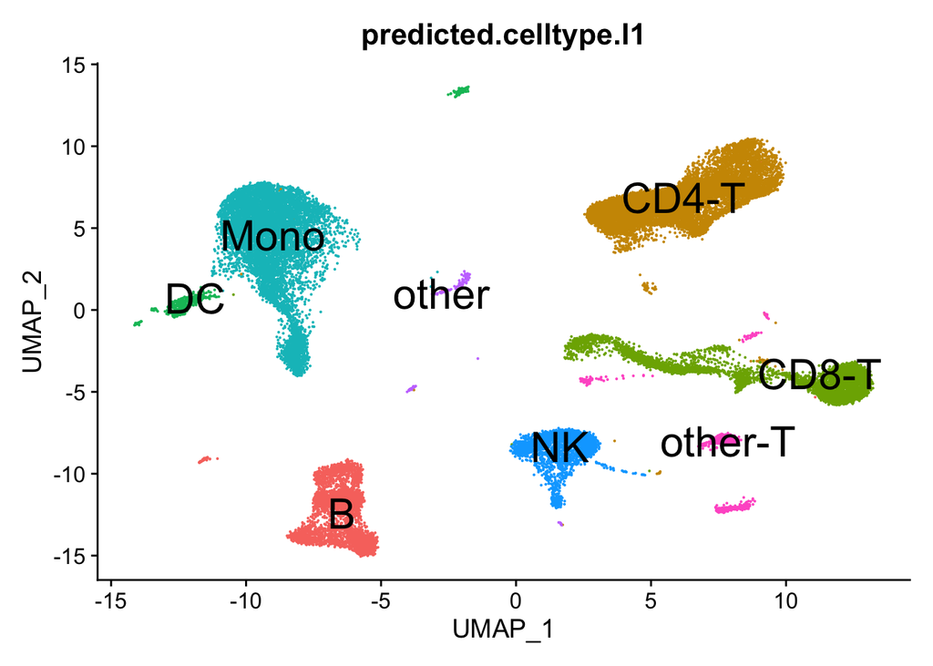

```r
DimPlot(pbmc, group.by = "predicted.celltype.l1", label = TRUE, label.size = 8) + NoLegend()
```

```r
## let's take a look at a summary of the level1 cell types by original sample
kable(table(pbmc$orig.ident, pbmc$predicted.celltype.l1))
```

|  | B | CD4-T | CD8-T | DC | Mono | NK | other | other-T |
| --- | --- | --- | --- | --- | --- | --- | --- | --- |
| PBMC10K | 424 | 3102 | 775 | 51 | 1225 | 111 | 35 | 104 |
| PBMC20K | 801 | 5373 | 1811 | 124 | 2274 | 230 | 42 | 203 |
| PBMC4K | 605 | 1033 | 400 | 138 | 1024 | 181 | 10 | 183 |
| PBMC8K | 1209 | 1787 | 894 | 229 | 2031 | 293 | 27 | 335 |
| pbmcRenalControl | 523 | 2568 | 908 | 59 | 303 | 252 | 13 | 24 |
| pbmcRenalPatient | 308 | 2219 | 683 | 59 | 1164 | 1221 | 20 | 98 |

## Diet Seurat

Let’s remove everthing we don’t need from the object.

‘DietSeurat’ is perfect for this task, keeping only the RNA assay and saving disk space

```r
## we got a high quality cell assignment and now we can trim down the data to save space
## set default assay
DefaultAssay(pbmc) <- "RNA"
## run dietseurat and only keep original counts
pbmc <- DietSeurat(pbmc, assays = "RNA")
```

## Save Data

Save data for downstream processing and analysis

```r
## and let's write the cleaned up object
saveRDS(pbmc, paste(params$workingDirectory, params$outputFile, sep = ""))
```